# Flights Dataset Exploration

## by Lujain Kotb

## Preliminary Wrangling

### What is/are the main feature(s) of interest in your dataset?

> The main features of interest to investigate the reasons and frequencies for arrivals/delays are: arr_flights,arr_del15 along with their delay amount in minutes for each reason(arr_delay,carrier_delay,...)

### What features in the dataset do you think will help support your investigation into your feature(s) of interest?

> Features that would support the investigation are:

> 1- Carrier (So we can group by this variable and have insights into each carrier's statistics

> 2- Airport (So we can find out if there is any airport that has certain types of problems occuring frequently, or the airports with highest delay statistics in general so we can address the problem at that airport thereof.

## Univariate Exploration

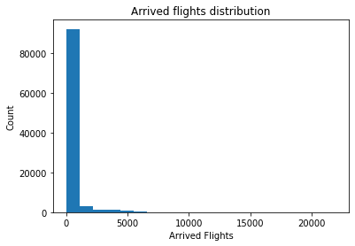

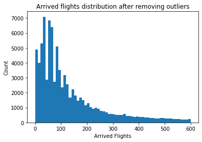

- Looking at the distribution we can see that it is multimodal with a generally skewed to the right distribution
- Now let's see how weather conditions have affected delays

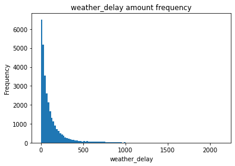

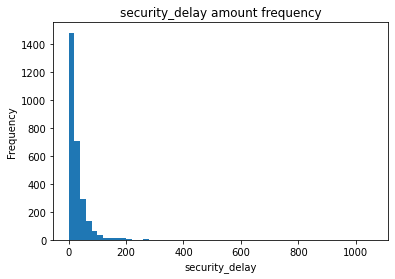

- From looking at the histogram we can tell that security requirements have a smaller effect on delay than weather conditions in general, we know that by looking the limits in the histogram as well as the slope of drop in the curve and where it starts to drop at low levels.

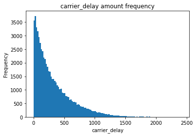

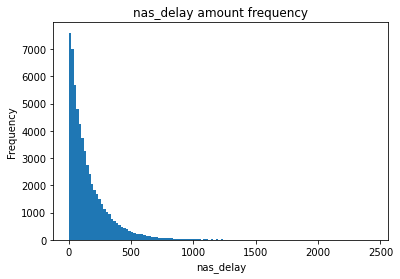

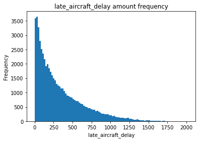

- We see the rest of the histograms depicting almost the same trend and distribution, right skewed, unimodal distributions.

## Bivariate Exploration

- To get an overview of the data we will start by plotting a Grid depicitng the general relationships amongst variables.

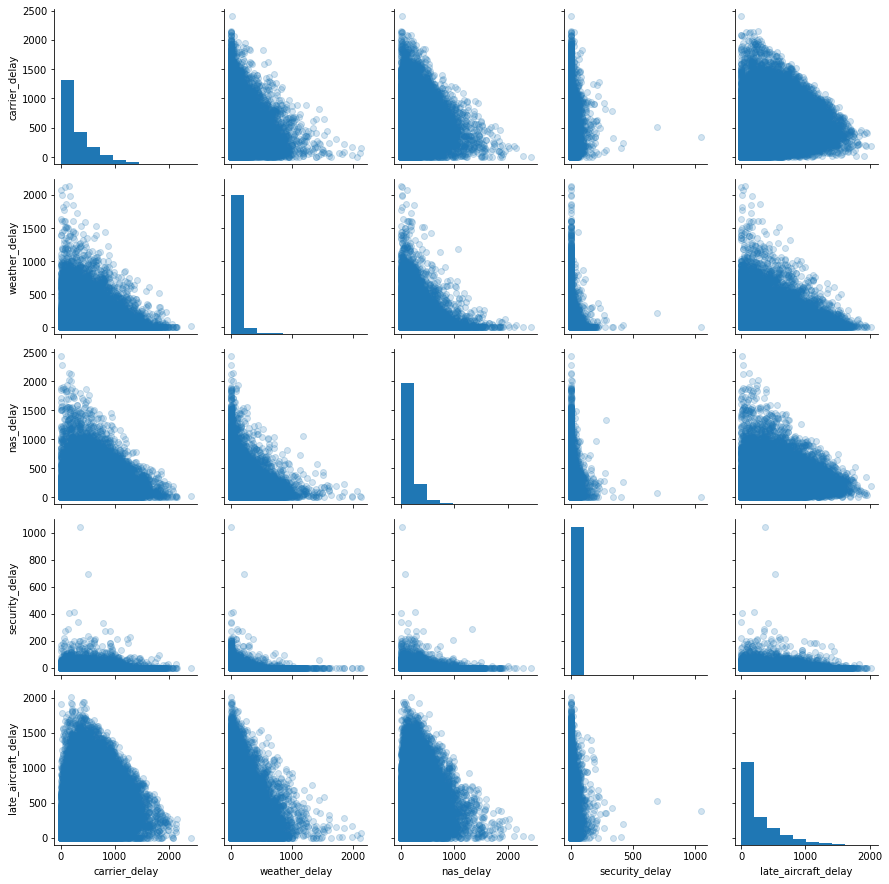

> Now let's also generate a heatmap from correlation amongst variables

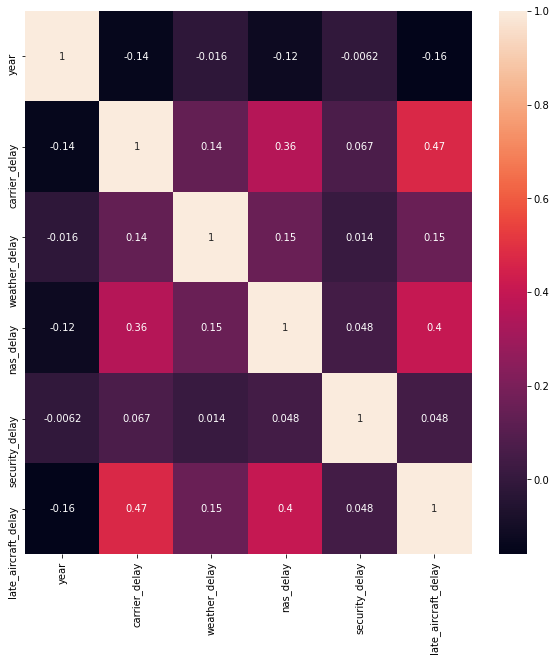

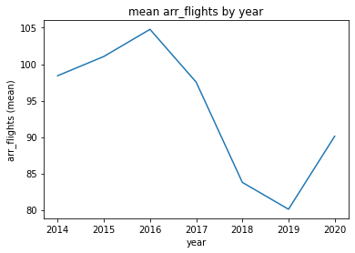

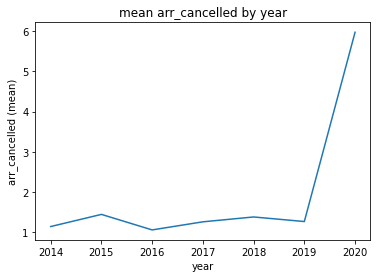

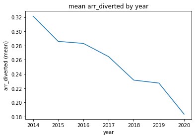

- There's an interesting trend here in the year 2020 which has witnesses the largest cancellation rate and lowest diversion rate in all years being examined this can be depicted as due to the pandemic

## Multivariate Exploration

- Let's try to explore more to see if we can find trends in security delays.

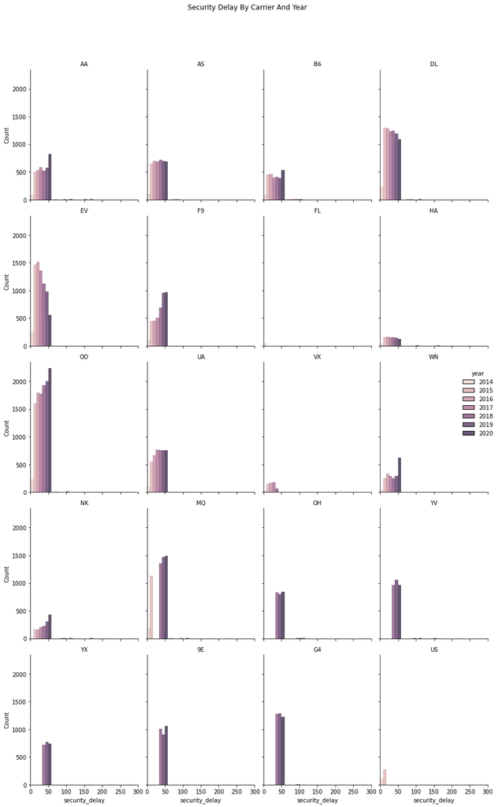

- From the figure we can see that most security delays lie around the 50 mins range with FL airline suffering from almost no security delays in the last few years. There doesn't seem to be a trend in security and has a different distribution across years and carrier combinations.

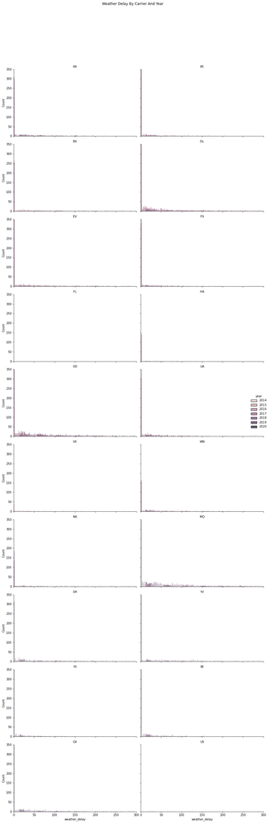

- It's not easy to spot but if you use an abstract look you will see that the general trend of the year 2020 for the weather_delay, represented in the darkest color is quite less over almost all of the carriers being represented.

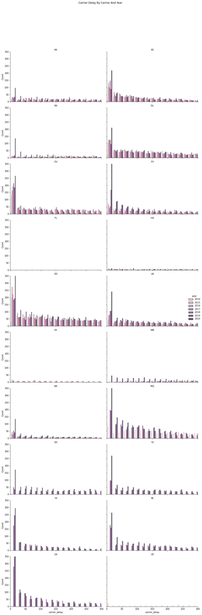